# Proyecto Final - Parte 5

Valor en Riesgo (VaR) y Expected Shortfall de un portafolio

Nicole Getzabel Flores Godínez

Andrea Gutiérrez Rentería

Isaac Emiliano Meza López

María Fernanda Gómez Flores

# 1 Introducción

En las entregas anteriores analizamos los principales riesgos financieros asociados con Alsea, el comportamiento histórico de su acción y las características estadísticas de sus rendimientos. En la tercera parte utilizamos el movimiento browniano geométrico (GBM) para estudiar posibles trayectorias del precio, mientras que en la cuarta estimamos la volatilidad mediante MA, EWMA, DDEWMA y modelos ARCH/GARCH. Al comparar sus resultados fuera de muestra encontramos que una medida con menor error promedio no necesariamente responde mejor cuando aumentan los movimientos extremos.

En esta quinta entrega ampliamos el análisis del riesgo de un activo individual a un portafolio de seis acciones. Nuestro objetivo es estimar las pérdidas potenciales mediante el Valor en Riesgo (VaR) con simulación histórica y con un enfoque paramétrico basado en normalidad, y contrastar ambas metodologías a distintos horizontes y niveles de confianza. También utilizamos backtesting para evaluar si sus estimaciones se corresponden con las pérdidas observadas y examinamos cómo cambia la exposición al riesgo al modificar los pesos del portafolio.

Primero construimos un portafolio con una inversión de $100,000 MXN en cada uno de los seis activos y calculamos sus rendimientos. Después estimamos el VaR no paramétrico y paramétrico para horizontes de 1, 5, 10 y 20 días. A continuación comparamos ambos modelos mediante backtesting, buscamos una combinación de pesos que minimice el VaR y estimamos, para una posición individual de $100,000 MXN en ALSEA, el VaR por Monte Carlo y el Expected Shortfall al 99%. Finalmente, interpretamos las diferencias entre los resultados, especialmente su capacidad para representar eventos extremos, sus supuestos y sus implicaciones para la toma de decisiones financieras.

# 2 Construcción del portafolio

## 2.1 Selección de los seis activos y preparación de datos

Partimos de las seis emisoras asignadas a los equipos del curso: Orbia, Walmart de México, Grupo México, Alsea, Grupo Aeroportuario del Pacífico y Banco del Bajío. Para mantener la consistencia con las entregas anteriores y con los ejercicios de clase, descargamos precios de cierre y precios ajustados mediante `quantmod`. Buscamos todas las fechas disponibles desde el año 2000, en lugar de imponer un corte en 2021, y retenemos las sesiones comunes con cotizaciones válidas. La ventana histórica efectiva comienza cuando ya cotizan las seis emisoras. Así evitamos combinar movimientos bursátiles de días distintos.

El código conserva la estructura de descarga mediante `getSymbols`, extracción del precio ajustado con `Ad` y cálculo de rendimientos que utilizamos previamente.

**Primera sesión común:** 2017-06-08  
**Última sesión común:** 2026-11-24

## 2.2 Inversión inicial y valor del portafolio

Tomamos como fecha de análisis el último cierre disponible dentro del periodo seleccionado. Asignamos un capital inicial de $100,000 MXN a cada activo, por lo que el valor de referencia del portafolio es $600,000 MXN y cada posición representa una sexta parte de la inversión. La cantidad teórica de acciones se obtiene dividiendo el monto asignado entre el **precio de cierre** de cada acción en la fecha de análisis, mientras que los rendimientos y escenarios de riesgo se calculan con **precios ajustados** para incorporar correctamente los cambios por dividendos y eventos corporativos. El valor actual del portafolio es de 600,000 MXN por construcción. Trabajamos con cantidades fraccionarias teóricas para representar exactamente la inversión de 100,000 MXN por emisora, sin comisiones ni costos de transacción.

Composición inicial al 2026-11-24

| Activo | Precio_cierre | Numero_de_acciones | Inversion_MXN | Peso |
| --- | --- | --- | --- | --- |
| ORBIA.MX | 20.83 | 4,800.7681 | 100,000 | 16.67 |
| WALMEX.MX | 53.53 | 1,868.1114 | 100,000 | 16.67 |
| GMEXICOB.MX | 188.23 | 531.2650 | 100,000 | 16.67 |
| ALSEA.MX | 58.38 | 1,712.9154 | 100,000 | 16.67 |
| GAPB.MX | 442.55 | 225.9632 | 100,000 | 16.67 |
| BBAJIOO.MX | 55.51 | 1,801.4773 | 100,000 | 16.67 |

```
## Valor inicial del portafolio (MXN): 600,000
```

## 2.3 Rendimientos del portafolio

Para medir el riesgo de la asignación inicial utilizamos los rendimientos simples de los seis activos y los ponderamos por sus pesos iguales de 16.67%. Esto equivale a valorar cada escenario con las posiciones actuales y evita confundir los pesos iniciales con los pesos que habría tenido una cartera histórica sin rebalanceo. Conservamos, adicionalmente, la serie de valor de una cartera de cantidades fijas y los rendimientos logarítmicos para la simulación individual.

Resumen de rendimientos diarios del portafolio

| Observaciones | Rendimiento_medio_diario | Volatilidad_diaria |
| --- | --- | --- |
| 2,378 | 0.000498 | 0.012538 |

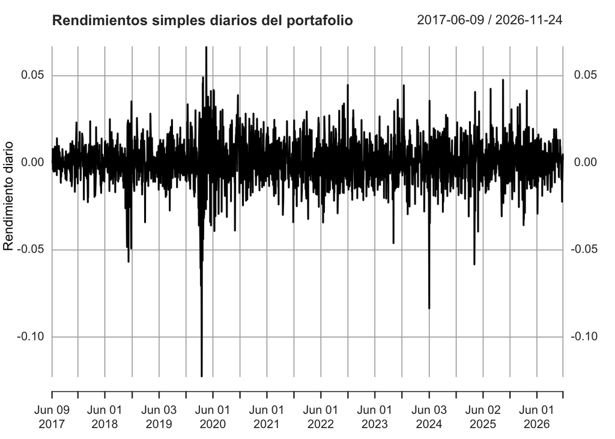

# 3 VaR no paramétrico: simulación histórica

## 3.1 Escenarios históricos de pérdidas y ganancias

Para estimar el VaR histórico no suponemos una distribución teórica de los rendimientos. Reproducimos sobre las posiciones actuales los cambios conjuntos que las seis acciones tuvieron en cada ventana observada. Esta decisión mantiene la dependencia entre activos durante caídas simultáneas. La ganancia o pérdida de un escenario con horizonte $h$ se define como

$$PyG_{t,h}=V_0\sum_{i=1}^{6}w_i
\left(\frac{P_{i,t}}{P_{i,t-h}}-1\right).$$

La muestra histórica disponible para el portafolio comprende desde **08/06/2017** hasta **24/11/2026**. Los escenarios se construyen con las fechas comunes del panel; para $h>1$, se emplean bloques de $h$ sesiones históricas, **sin escalar artificialmente el cuantil diario**. Los bloques traslapados preservan más observaciones, aunque no equivalen a escenarios independientes.

## 3.2 VaR histórico a 1, 5, 10 y 20 días

Expresamos el VaR como una **pérdida positiva**: es el negativo del cuantil inferior de la distribución de ganancias y pérdidas. Por ejemplo, al 99% el umbral se obtiene a partir del cuantil del 1% de $PyG$. Utilizamos toda la muestra disponible para cada horizonte.

VaR por simulación histórica del portafolio

| Horizonte_dias | Confianza | Escenarios | VaR_MXN | VaR_pct |
| --- | --- | --- | --- | --- |
| 1 | 95% | 2,378 | 10,579.95 | 1.763 |
| 1 | 97.5% | 2,378 | 14,181.90 | 2.364 |
| 1 | 99% | 2,378 | 19,633.74 | 3.272 |
| 5 | 95% | 2,374 | 24,488.73 | 4.081 |
| 5 | 97.5% | 2,374 | 32,012.80 | 5.335 |
| 5 | 99% | 2,374 | 42,503.98 | 7.084 |
| 10 | 95% | 2,369 | 33,325.43 | 5.554 |
| 10 | 97.5% | 2,369 | 43,607.64 | 7.268 |
| 10 | 99% | 2,369 | 60,286.36 | 10.048 |
| 20 | 95% | 2,359 | 46,121.35 | 7.687 |
| 20 | 97.5% | 2,359 | 62,374.51 | 10.396 |
| 20 | 99% | 2,359 | 109,095.87 | 18.183 |

## 3.3 Distribución y VaR al 95%, 97.5% y 99%

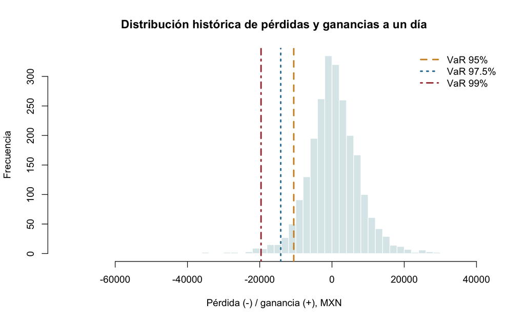

El VaR histórico al 99% a un día alcanza **19,633.74 MXN**, equivalente al **3.272%** del capital. Esto no significa que la pérdida máxima esté limitada a esa cantidad: el 1% de los escenarios históricos está en la cola que rebasa el umbral.

# 4 VaR paramétrico

## 4.1 Supuesto normal, volatilidades y matriz de covarianzas

Para el método paramétrico usamos los rendimientos **simples diarios** y calculamos sus covarianzas con los últimos seis meses de calendario disponibles hasta la fecha de valuación. La covarianza considera las correlaciones entre las emisoras; sumar volatilidades individuales ignoraría el beneficio o costo de los movimientos conjuntos.

$$\sigma_p=\sqrt{\mathbf{w}^{\top}\Sigma\mathbf{w}}.$$

Volatilidad diaria: últimos seis meses

| Activo | Volatilidad_diaria_pct |
| --- | --- |
| ORBIA.MX | 1.776 |
| WALMEX.MX | 1.380 |
| GMEXICOB.MX | 2.125 |
| ALSEA.MX | 1.590 |
| GAPB.MX | 1.982 |
| BBAJIOO.MX | 1.325 |

Matriz de covarianzas diarias, en puntos porcentuales al cuadrado

|  | ORBIA.MX | WALMEX.MX | GMEXICOB.MX | ALSEA.MX | GAPB.MX | BBAJIOO.MX |
| --- | --- | --- | --- | --- | --- | --- |
| ORBIA.MX | 3.1525 | 0.0095 | 0.5341 | 0.2839 | 0.1837 | 0.4331 |
| WALMEX.MX | 0.0095 | 1.9053 | -0.3476 | 0.5585 | 0.4349 | 0.0244 |
| GMEXICOB.MX | 0.5341 | -0.3476 | 4.5136 | 0.1051 | 0.7171 | 0.4212 |
| ALSEA.MX | 0.2839 | 0.5585 | 0.1051 | 2.5268 | 0.2075 | 0.3577 |
| GAPB.MX | 0.1837 | 0.4349 | 0.7171 | 0.2075 | 3.9276 | 0.5128 |
| BBAJIOO.MX | 0.4331 | 0.0244 | 0.4212 | 0.3577 | 0.5128 | 1.7560 |

La ventana incluye **129** rendimientos diarios, del **25/05/2026** al **24/11/2026**. La volatilidad diaria del portafolio es **0.86%**.

## 4.2 VaR paramétrico a 1, 5, 10 y 20 días

Adoptamos una media diaria igual a cero para aislar el riesgo de dispersión a corto plazo, y declaramos ese supuesto en lugar de presentarlo como una propiedad de los datos.

VaR paramétrico normal del portafolio

| Horizonte_dias | Confianza | VaR_MXN | VaR_pct |
| --- | --- | --- | --- |
| 1 | 95% | 8,491.96 | 1.415 |
| 1 | 97.5% | 10,118.79 | 1.686 |
| 1 | 99% | 12,010.33 | 2.002 |
| 5 | 95% | 18,988.59 | 3.165 |
| 5 | 97.5% | 22,626.30 | 3.771 |
| 5 | 99% | 26,855.92 | 4.476 |
| 10 | 95% | 26,853.92 | 4.476 |
| 10 | 97.5% | 31,998.42 | 5.333 |
| 10 | 99% | 37,980.01 | 6.330 |
| 20 | 95% | 37,977.18 | 6.330 |
| 20 | 97.5% | 45,252.60 | 7.542 |
| 20 | 99% | 53,711.85 | 8.952 |

## 4.3 Escalamiento temporal

Bajo varianza constante y ausencia de autocorrelación de los rendimientos, la varianza acumulada durante $h$ sesiones crece proporcionalmente a $h$, y su desviación estándar aumenta con $\sqrt{h}$:

$$VaR_{c,h}=V_0\,\Phi^{-1}(c)\,\sigma_p\sqrt{h}.$$

Este escalamiento no es una identidad empírica: puede fallar si existe agrupamiento de volatilidad, cambios de régimen o dependencia temporal. Por ello, más adelante contrastamos sus resultados con los bloques efectivamente observados en la simulación histórica.

Comparación de VaR histórico y normal

| Horizonte_dias | Confianza | VaR_MXN_Historico | VaR_MXN_Normal | Diferencia_MXN |
| --- | --- | --- | --- | --- |
| 1 | 95% | 10,579.95 | 8,491.96 | 2,088.00 |
| 1 | 97.5% | 14,181.90 | 10,118.79 | 4,063.11 |
| 1 | 99% | 19,633.74 | 12,010.33 | 7,623.40 |
| 10 | 95% | 33,325.43 | 26,853.92 | 6,471.50 |
| 10 | 97.5% | 43,607.64 | 31,998.42 | 11,609.22 |
| 10 | 99% | 60,286.36 | 37,980.01 | 22,306.35 |
| 20 | 95% | 46,121.35 | 37,977.18 | 8,144.17 |
| 20 | 97.5% | 62,374.51 | 45,252.60 | 17,121.91 |
| 20 | 99% | 109,095.87 | 53,711.85 | 55,384.03 |
| 5 | 95% | 24,488.73 | 18,988.59 | 5,500.14 |
| 5 | 97.5% | 32,012.80 | 22,626.30 | 9,386.50 |
| 5 | 99% | 42,503.98 | 26,855.92 | 15,648.05 |

## 4.4 Comparación con la misma muestra histórica

Hasta aquí, el VaR histórico utiliza la muestra completa y el normal los últimos seis meses. Para aislar el efecto de elegir ventanas distintas, calculamos también un VaR normal utilizando todos los rendimientos simples del periodo común. Así comparamos los métodos con la misma información, a un día y al 99%, manteniendo el capital y los pesos originales.

VaR diario al 99%: distribución y ventana

| Metodo | VaR_99_MXN |
| --- | --- |
| Histórico: muestra completa | 19,633.74 |
| Normal: muestra completa | 17,500.41 |
| Normal: últimos seis meses | 12,010.33 |

El VaR normal con toda la muestra fue de **17,500.41 MXN**. Al compararlo con el VaR histórico de la misma muestra, la diferencia ya no se explica por la longitud de la ventana, sino por el modo de estimar el cuantil de pérdida. Al comparar los dos modelos normales, observamos el efecto de utilizar una ventana más reciente.

# 5 Backtesting del VaR a un día

## 5.1 Separación de estimación y evaluación

El backtesting evalúa los pronósticos fuera de muestra durante las sesiones de 2026 hasta el corte de valuación, usando exclusivamente rendimientos anteriores a cada sesión. Elegimos este periodo, en lugar de únicamente las veinte sesiones de octubre, para disponer de más observaciones de violaciones raras al 99%. La evaluación es secuencial: la información del día evaluado nunca entra al VaR que se contrasta con su pérdida.

En cada fecha el VaR histórico se recalcula con **toda la historia anterior disponible** y el normal con una **ventana móvil de seis meses**. Comparamos ambas estimaciones con el mismo capital de referencia de 600,000 MXN y los mismos pesos equiponderados.

## 5.2 Violaciones observadas y esperadas

Una violación se registra cuando la pérdida real supera el VaR de ese día: $-PyG_t > VaR_t$. Si el método está correctamente calibrado, para $n$ evaluaciones al nivel $c$ esperaríamos $n(1-c)$ violaciones. Además del conteo, aplicamos la prueba de cobertura incondicional de Kupiec, que contrasta si la frecuencia observada es consistente con la probabilidad nominal.

Cobertura fuera de muestra del VaR diario

| Confianza | Metodo | Sesiones | Violaciones_observadas | Violaciones_esperadas | Frecuencia_observada_pct | P_valor_Kupiec |
| --- | --- | --- | --- | --- | --- | --- |
| 95% | Historico | 224 | 8 | 11.20 | 3.57 | 0.3022 |
| 95% | Normal | 224 | 7 | 11.20 | 3.12 | 0.1678 |
| 97.5% | Historico | 224 | 5 | 5.60 | 2.23 | 0.7937 |
| 97.5% | Normal | 224 | 6 | 5.60 | 2.68 | 0.8656 |
| 99% | Historico | 224 | 1 | 2.24 | 0.45 | 0.3499 |
| 99% | Normal | 224 | 3 | 2.24 | 1.34 | 0.6275 |

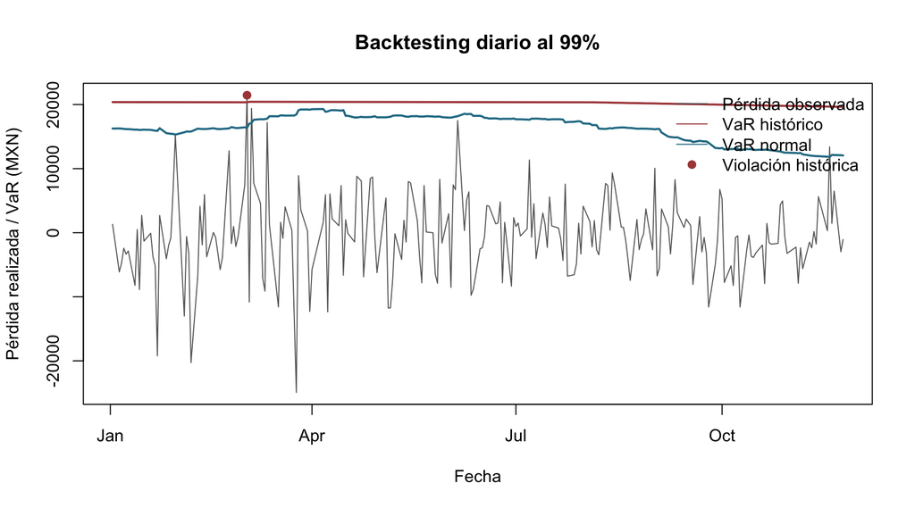

## 5.3 Evaluación comparativa

No basta con observar cuál método registra menos violaciones: una cantidad anormalmente baja puede indicar un VaR sistemáticamente excesivo. La prueba de Kupiec identifica desviaciones de la tasa nominal, pero no comprueba que las violaciones sean independientes ni evalúa, por sí sola, la magnitud de cada pérdida extrema.

Al **95%**, el modelo histórico presenta **8 violaciones** y el normal **7 violaciones**, frente a **11.20** esperadas. La prueba de Kupiec no rechaza la cobertura nominal de ninguno de los dos modelos al 5% de significancia; esto no prueba que los supuestos de distribución sean correctos.

Al **97.5%**, el modelo histórico presenta **5 violaciones** y el normal **6 violaciones**, frente a **5.60** esperadas. La prueba de Kupiec no rechaza la cobertura nominal de ninguno de los dos modelos al 5% de significancia; esto no prueba que los supuestos de distribución sean correctos.

Al **99%**, el modelo histórico presenta **1 violación** y el normal **3 violaciones**, frente a **2.24** esperadas. La prueba de Kupiec no rechaza la cobertura nominal de ninguno de los dos modelos al 5% de significancia; esto no prueba que los supuestos de distribución sean correctos.

## 5.4 Independencia de las excepciones

Kupiec evalúa la frecuencia de violaciones, pero no determina si se presentan agrupadas. La prueba de independencia de Christoffersen compara la frecuencia de transiciones entre días con y sin violaciones. Como al 99% ocurren muy pocas excepciones, solo reportamos un p-valor cuando hay suficientes transiciones para que la comparación tenga sentido.

Independencia de excepciones al 99%

| Modelo | LR | P_valor | Violaciones_consecutivas |
| --- | --- | --- | --- |
| Historico | NA | NA | 0 |
| Normal | NA | NA | 0 |

En esta evaluación, un **NA** significa que las violaciones son demasiado escasas para interpretar el contraste con seguridad. No significa que hayamos demostrado independencia. Incluso con más excepciones, la aproximación asintótica debe interpretarse con cautela en muestras cortas.

# 6 Optimización del portafolio

## 6.1 Objetivo y restricciones

Bajo el modelo normal con media cero, minimizar el VaR al 99% a un día equivale a minimizar $\mathbf{w}^{\top}\Sigma\mathbf{w}$. Seleccionamos esta medida porque incorpora covarianzas, tiene una solución global bajo restricciones convexas y permite contrastar claramente los pesos nuevos con la asignación inicial.

Restringimos la inversión a posiciones largas, con pesos que suman 100% y un máximo de 40% por emisora. Este último límite es una decisión de gestión para evitar que la minimización de varianza produzca una concentración excesiva.

Composición inicial y de mínimo VaR normal

| Activo | Peso_inicial_pct | Peso_optimo_pct | Monto_inicial_MXN | Monto_optimo_MXN |
| --- | --- | --- | --- | --- |
| ORBIA.MX | 16.67 | 13.40 | 100,000 | 80,377.66 |
| WALMEX.MX | 16.67 | 30.39 | 100,000 | 182,341.06 |
| GMEXICOB.MX | 16.67 | 11.34 | 100,000 | 68,043.93 |
| ALSEA.MX | 16.67 | 12.67 | 100,000 | 76,004.73 |
| GAPB.MX | 16.67 | 6.32 | 100,000 | 37,938.02 |
| BBAJIOO.MX | 16.67 | 25.88 | 100,000 | 155,294.61 |

## 6.2 Pesos óptimos y VaR mínimo

VaR normal diario al 99%, antes y después de optimizar

| Portafolio | Volatilidad_diaria_pct | VaR_normal_99_MXN |
| --- | --- | --- |
| Inicial | 0.860 | 12,010.33 |
| Optimizado | 0.803 | 11,213.99 |

La cartera optimizada reduce el VaR normal al 99% en **796.34 MXN**, equivalentes al **6.63%** del VaR inicial.

## 6.3 Riesgo y diversificación

Para evaluar la diversificación calculamos el **número efectivo de activos**: $N_{\mathrm{ef}}=1/\sum_i w_i^2$. Cuanto menor sea, más concentrada está la asignación. Asimismo, contrastamos ambas composiciones con la misma distribución histórica: minimizar el VaR normal no garantiza disminuir el VaR histórico.

Diversificación y sensibilidad al riesgo histórico

| Portafolio | Numero_efectivo_activos | Mayor_peso_pct | VaR_historico_99_MXN |
| --- | --- | --- | --- |
| Inicial | 6.00 | 16.67 | 19,633.74 |
| Optimizado | 4.76 | 30.39 | 18,264.89 |

La concentración pasa de **6** a **4.76** activos efectivos. El VaR histórico al 99% de la composición optimizada disminuye frente al inicial, resultado que confirma la importancia de verificar la solución bajo una metodología diferente de aquella que optimizamos.

## 6.4 Contribución de cada activo al VaR normal

Además de comparar los pesos, calculamos qué parte del VaR paramétrico corresponde a cada empresa, utilizando la descomposición de Euler. Para una cartera con media cero, la contribución de cada posición es:

$$RC_i=V_0\Phi^{-1}(0.99)
\frac{w_i(\Sigma\mathbf{w})_i}{\sigma_p}.$$

Aporte al VaR normal diario al 99%

| Activo | Inicial_MXN | Optimizado_MXN | Inicial_pct | Optimizado_pct |
| --- | --- | --- | --- | --- |
| ORBIA.MX | 2,071.36 | 1,502.26 | 17.25 | 13.40 |
| WALMEX.MX | 1,164.85 | 3,407.95 | 9.70 | 30.39 |
| GMEXICOB.MX | 2,678.19 | 1,271.74 | 22.30 | 11.34 |
| ALSEA.MX | 1,820.19 | 1,420.53 | 15.16 | 12.67 |
| GAPB.MX | 2,696.26 | 709.06 | 22.45 | 6.32 |
| BBAJIOO.MX | 1,579.49 | 2,902.45 | 13.15 | 25.88 |

En el portafolio inicial, **GAPB.MX** es la emisora que más contribuye al riesgo total, aunque todas reciben la misma inversión. Esto confirma que diversificar el capital en partes iguales no equivale a repartir el riesgo en partes iguales.

# 7 VaR individual de ALSEA mediante Monte Carlo

## 7.1 Posición de $100,000 MXN

Estudiamos una posición de 100,000 MXN en ALSEA.MX al cierre común del portafolio. Como la consigna exige una metodología **no paramétrica por Monte Carlo**, generamos 100,000 escenarios mediante remuestreo con reemplazo (*bootstrap*) de los rendimientos simples históricos de ALSEA, sin imponerles una distribución normal.

A diferencia de un GBM con shocks normales, este procedimiento preserva los rendimientos extremos de la muestra. Sin embargo, no produce pérdidas más severas que las históricas y el remuestreo individual no conserva el agrupamiento temporal de la volatilidad. Para aprovechar toda la historia del activo individual, utilizamos su propia serie ajustada desde su primera fecha disponible hasta el corte.

## 7.2 VaR Monte Carlo al 99%

El VaR individual estimado al **99%** para un día es de **5,566.42 MXN**, es decir, **5.566%** del valor invertido. El remuestreo se basó en **6810** rendimientos históricos del activo.

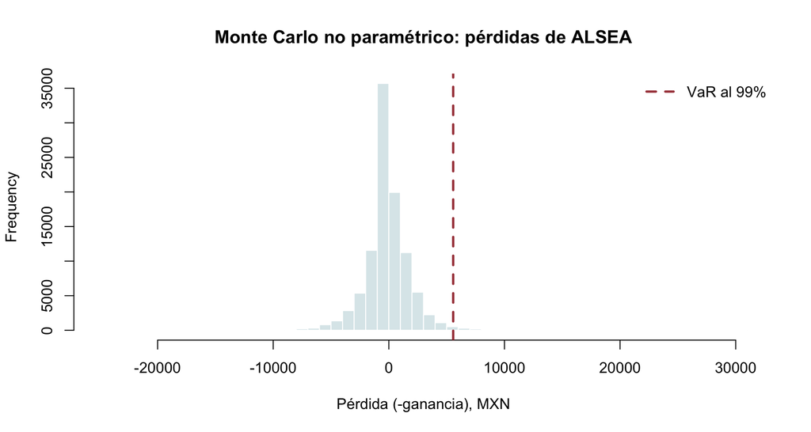

## 7.3 Expected Shortfall al 99%

El Expected Shortfall (ES) es la pérdida media del **1% peor** de escenarios. Para evitar ambigüedades en el umbral cuando el remuestreo repite algún rendimiento, promediamos exactamente los peores $n_{\mathrm{MC}}(1-0.99)$ resultados.

Riesgo individual de ALSEA por Monte Carlo, un día

| Medida | Monto_MXN | Porcentaje_posicion |
| --- | --- | --- |
| VaR 99% | 5,566.42 | 5.566 |
| Expected Shortfall 99% | 8,378.27 | 8.378 |

El ES al 99% alcanza **8,378.27 MXN**, equivalente al **8.378%** de la posición. El valor supera al VaR por **2,811.85 MXN**. El ES evidencia el costo medio condicionado a la cola, aunque la estimación sigue limitada por los episodios ya observados.

## 7.4 Monte Carlo con GBM como comparación

Para complementar el remuestreo histórico realizamos una segunda simulación, esta vez con la solución exacta del movimiento browniano geométrico utilizada en clase:

$$S_{t+1}=S_t\exp(\bar r_{\log}+\sigma_{\log} Z),\quad Z\sim N(0,1).$$

Utilizamos la media y la desviación estándar de los rendimientos logarítmicos **diarios** de ALSEA. Por eso cada escenario corresponde a un día, sin necesidad de volver a anualizar. A diferencia del bootstrap anterior, aquí suponemos shocks normales.

ALSEA: comparación de Monte Carlo al 99%

| Metodo | VaR_99_MXN | ES_99_MXN |
| --- | --- | --- |
| Remuestreo histórico (bootstrap) | 5,566.42 | 8,378.27 |
| Modelo GBM normal | 4,794.02 | 5,479.17 |

El GBM estima un VaR de **4,794.02 MXN** y un Expected Shortfall de **5,479.17 MXN**. La diferencia respecto al bootstrap refleja la forma de generar los rendimientos: uno reutiliza movimientos históricos y el otro simula una distribución normal de rendimientos logarítmicos. Ambos dependen de sus supuestos y del periodo de información.

# 8 Análisis e interpretación financiera

## 8.1 Diferencias entre metodologías

El histórico utiliza la distribución empírica conjunta de los seis activos a cada horizonte; el normal utiliza una matriz de covarianzas reciente y un supuesto de distribución. Por lo tanto, las diferencias no se atribuyen exclusivamente a la normalidad: también intervienen las **ventanas de información distintas** y el escalamiento.

A **1 día** y **99%**, el VaR histórico es **$19,633.74** y el normal **$12,010.33**. El modelo **histórico** estima el mayor límite, con una diferencia absoluta de **$7,623.40**.

A **5 días** y **99%**, el VaR histórico es **$42,503.98** y el normal **$26,855.92**. El modelo **histórico** estima el mayor límite, con una diferencia absoluta de **$15,648.05**.

A **10 días** y **99%**, el VaR histórico es **$60,286.36** y el normal **$37,980.01**. El modelo **histórico** estima el mayor límite, con una diferencia absoluta de **$22,306.35**.

A **20 días** y **99%**, el VaR histórico es **$109,095.87** y el normal **$53,711.85**. El modelo **histórico** estima el mayor límite, con una diferencia absoluta de **$55,384.03**.

## 8.2 Eventos extremos y conservadurismo

El histórico puede capturar pérdidas extremas efectivamente registradas y caídas simultáneas, siempre que estén presentes en la muestra. El normal representa las colas a partir de su desviación estándar, por lo que puede subestimarlas ante asimetría o colas pesadas. Sin embargo, **no puede afirmarse de antemano** cuál será más conservador: esa conclusión depende del horizonte, nivel de confianza y periodo.

Para estudiar las pérdidas extremas sin atribuirlas automáticamente a una noticia, identificamos las cinco peores sesiones de la cartera y descomponemos su pérdida entre las seis posiciones. El impacto por activo se estima con la exposición de 100,000 MXN multiplicada por su rendimiento simple observado en la jornada.

Cinco sesiones de mayor pérdida: contribuciones por emisora en MXN

| Fecha | Perdida_cartera_MXN | ORBIA.MX | WALMEX.MX | GMEXICOB.MX | ALSEA.MX | GAPB.MX | BBAJIOO.MX |
| --- | --- | --- | --- | --- | --- | --- | --- |
| 2020-03-17 | 73,786.59 | -8,441.00 | -4,330.08 | -2,569.46 | -30,722.90 | -17,379.57 | -10,343.59 |
| 2020-03-18 | 56,502.33 | -16,830.67 | 1,799.30 | -2,851.02 | -22,782.61 | -11,271.51 | -4,565.83 |
| 2024-06-03 | 50,112.10 | -10,068.32 | -5,772.54 | -6,505.53 | -7,583.64 | -9,458.66 | -10,723.40 |
| 2020-03-12 | 42,299.58 | -4,445.13 | -6,112.80 | -2,067.14 | -12,631.00 | -14,408.01 | -2,635.49 |
| 2020-03-09 | 36,285.39 | -8,993.89 | -2,921.74 | -8,607.06 | -5,566.40 | -5,306.64 | -4,889.65 |

La tabla permite distinguir pérdidas generalizadas de jornadas dominadas por una sola emisora. Las aportaciones negativas identifican acciones que restaron valor, y las positivas identifican posiciones que amortiguaron la pérdida. No atribuimos causalidad a acontecimientos específicos sin consultar información económica o corporativa de la fecha correspondiente.

La mayor pérdida diaria conjunta de la muestra equivale a **73,786.59 MXN**, correspondiente al **17/03/2020**. En **12 de 12** comparaciones, el VaR histórico es superior al normal. Una explicación plausible de esta diferencia es el **distinto periodo de calibración**: el histórico incorpora caídas intensas de toda la muestra, mientras que el paramétrico estima su matriz de covarianzas con los seis meses previos al corte y después aplica una aproximación normal. Por lo tanto, la diferencia no debe interpretarse como una prueba aislada de que la distribución normal siempre subestima el riesgo.

La jornada del **17 de marzo de 2020** coincide con el episodio de volatilidad asociado a la pandemia de COVID-19. La Bolsa Mexicana de Valores retrocedió cerca de 3.1%, mientras que fuentes periodísticas reportaron desplomes especialmente intensos en ALSEA y GAP. De acuerdo con La Jornada (2020), la caída del mercado mexicano ocurrió en un contexto de preocupación por los efectos económicos de la pandemia. Esta información proporciona **contexto**, no una identificación causal del rendimiento de cada acción.

En nuestro ejercicio, en esa sesión ALSEA aportó una pérdida de **30,722.90 MXN** y GAP otra de **17,379.57 MXN**. Las seis posiciones registraron contribuciones negativas; por ello la diversificación entre esas emisoras no evitó la pérdida conjunta.

Otro episodio fue el **3 de junio de 2024**, cuando la cartera sufrió una pérdida histórica de **50,112.10 MXN**. Ese día el IPC mexicano cayó aproximadamente 6% tras los resultados electorales y las preocupaciones del mercado por la composición del Congreso; la coincidencia ayuda a interpretar la exposición a un choque de mercado nacional, sin afirmar que una sola noticia determinó todos los retornos. El Economista (2024) documenta la caída del índice bursátil en esa sesión, después de las elecciones.

Estos dos episodios ilustran **riesgo sistemático**: cuando varias emisoras caen a la vez, los beneficios habituales de diversificar pueden reducirse precisamente cuando más se necesitan.

## 8.3 Subestimación del riesgo

Un VaR subestimado puede llevar a reservar poca liquidez y capital para absorber pérdidas; también puede provocar decisiones de tamaño de posición inapropiadas o ventas forzadas durante episodios de estrés. Por otro lado, sobreestimar permanentemente el VaR inmoviliza capital y reduce la capacidad de invertir. Por eso buscamos una estimación **bien calibrada**, no sencillamente la más alta.

## 8.4 Resultados del backtesting

Las violaciones registradas permiten contrastar los límites con pérdidas reales. Comparamos observadas y esperadas, la prueba de Kupiec y el tamaño de las pérdidas que exceden el VaR. Una frecuencia compatible con la nominal es una condición útil, pero no suficiente, para confiar en un modelo bajo escenarios futuros de estrés.

Severidad de las violaciones al 99%

| Modelo | Excepciones_99 | Exceso_medio_MXN | Exceso_maximo_MXN |
| --- | --- | --- | --- |
| Historico | 1 | 1,106.90 | 1,106.90 |
| Normal | 3 | 2,972.43 | 5,073.68 |

## 8.5 Lectura conjunta de las comparaciones adicionales

El VaR normal con toda la historia permitió separar el efecto de la ventana de estimación del supuesto de distribución. La contribución de cada activo mostró que asignar el mismo capital a las empresas no significa asignarles el mismo riesgo. La prueba de independencia añadió una revisión del agrupamiento de violaciones, aunque reconocemos que al 99% son pocas para obtener conclusiones definitivas.

Finalmente, el Monte Carlo con GBM complementó el remuestreo histórico de Alsea: comparar ambos métodos permite ver cómo cambian el VaR y el Expected Shortfall cuando suponemos una distribución de rendimientos logarítmicos normales en lugar de utilizar los movimientos ya observados.

# 9 Conclusión

En esta quinta parte del proyecto pasamos de analizar el riesgo de Alsea de manera individual a estudiar cómo se comporta un portafolio formado por seis empresas mexicanas. Con una inversión inicial de $100,000 MXN en cada una de las seis emisoras, construimos una cartera de $600,000 MXN y calculamos sus posibles pérdidas con dos metodologías. Lo primero que observamos es que el riesgo depende tanto del comportamiento de cada empresa como de la manera en que se mueven todas al mismo tiempo. Por eso no basta con tener varias acciones: también importa qué tan relacionadas están sus pérdidas.

Al comparar los resultados encontramos que el VaR histórico a un día y al 99% fue de **19,633.74 MXN**, mientras que el VaR paramétrico fue de **12,010.33 MXN**. En nuestro caso, el histórico dio una estimación mayor. Esto tiene sentido porque incorpora episodios de pérdidas fuertes observados en toda la historia disponible, mientras que el normal se basa en la volatilidad y las covarianzas de los últimos seis meses, además de asumir una distribución normal. Sin embargo, no concluimos que uno siempre sea más conservador: ambos resultados dependen de los datos, el periodo de estimación y el horizonte considerado. Al aumentar el plazo de 1 a 5, 10 y 20 días, también aumentan las pérdidas potenciales, aunque el método histórico utiliza movimientos acumulados realmente observados y el normal se escala con la raíz del tiempo.

El backtesting nos permitió ir más allá de comparar cifras y revisar cómo se habrían comportado estas estimaciones frente a pérdidas que todavía no se conocían cuando se calculó cada pronóstico. Durante **224 sesiones** de evaluación al 99%, el método histórico registró **1** violación y el paramétrico **3** violaciones, frente a **2.24** esperadas. La prueba de Kupiec no rechazó la cobertura nominal de ninguno de los dos modelos al 5% de significancia. Aun así, consideramos que el número de sesiones es limitado para sacar conclusiones definitivas sobre pérdidas que se esperan en aproximadamente el 1% de los días. También revisamos qué tan grandes fueron las pérdidas que superaron cada límite, porque contar violaciones por sí solo no muestra toda la severidad del riesgo.

La optimización mostró que modificar los pesos sí puede ayudar a reducir el riesgo medido por el modelo normal. El VaR diario al 99% pasó de **12,010.33 MXN** a **11,213.99 MXN**, una disminución de **6.63%**. Nuestro resultado corresponde al VaR paramétrico optimizado, por lo que también revisamos su efecto bajo la simulación histórica. Pero también observamos que la cartera quedó más concentrada, pues su número efectivo de activos pasó de **6** a **4.76**. Esto nos hizo ver que minimizar una medida de riesgo no significa mejorar todas las características del portafolio: una estrategia puede reducir la volatilidad estimada y, al mismo tiempo, depender más de unas cuantas empresas.

Al revisar los días con pérdidas más grandes encontramos que los acontecimientos externos pueden afectar a varias acciones simultáneamente. El caso más claro fue el **17/03/2020**, cuando la pérdida estimada del portafolio alcanzó **73,786.59 MXN**. Al relacionar este resultado con la crisis de COVID-19 y compararlo con otros episodios de tensión del mercado, entendimos por qué la diversificación no elimina el riesgo sistemático. En momentos de incertidumbre, empresas de sectores diferentes pueden registrar caídas al mismo tiempo y generar pérdidas mayores a las que esperaríamos en condiciones normales.

Por último, al analizar únicamente una inversión de $100,000 MXN en Alsea mediante Monte Carlo no paramétrico, estimamos un VaR al 99% de **5,566.42 MXN** y un Expected Shortfall de **8,378.27 MXN**. La diferencia es importante porque el VaR señala un umbral de pérdida, mientras que el Expected Shortfall nos permite estimar qué tan fuertes serían, en promedio, las pérdidas dentro del peor 1% de escenarios. Esto confirma que para entender el riesgo no debemos fijarnos solamente en un límite, sino también en lo que puede suceder cuando se rebasa.

En general, lo más importante que aprendimos es que **medir el riesgo no consiste en encontrar una sola cifra que describa todo lo que puede pasar**. El VaR histórico, el paramétrico, el backtesting, la optimización, las simulaciones de Monte Carlo y el Expected Shortfall responden preguntas distintas y se complementan. Para tomar una decisión financiera utilizaríamos el VaR histórico como referencia de los choques que ya han ocurrido, el paramétrico para seguir los cambios recientes de volatilidad y el backtesting para comprobar si las estimaciones continúan siendo razonables. También consideraríamos las pérdidas extremas, porque el hecho de que una pérdida sea poco probable no significa que sus consecuencias sean pequeñas. Así, esta parte del proyecto nos permitió pasar de observar la incertidumbre en Alsea a medirla y evaluar cómo administrarla en un portafolio.

# 10 Referencias

**Datos y metodología**

Yahoo Finance. (2026). *Precios históricos diarios ajustados y de cierre de ORBIA.MX, WALMEX.MX, GMEXICOB.MX, ALSEA.MX, GAPB.MX y BBAJIOO.MX* [Datos de mercado]. https://finance.yahoo.com/

Ryan, J. A., y Ulrich, J. M. (s. f.). *quantmod: Quantitative Financial Modelling Framework* [Paquete de R]. CRAN. https://cran.r-project.org/package=quantmod

**Eventos relevantes del mercado**

La Jornada. (17 de marzo de 2020). *Peso cierra con nuevo mínimo histórico frente al dólar*. https://www.jornada.com.mx/noticia/2020/03/17/economia/peso-cierra-con-nuevo-minimo-historico-frente-al-dolar-2981

La Jornada. (18 de marzo de 2020). *Toca el peso nuevo mínimo histórico; el dólar alcanzó $23.16, dice el BdeM*. https://www.jornada.com.mx/2020/03/18/economia/023n2eco

El Economista. (3 de junio de 2024). *Bolsas caen 6%, el peor día desde marzo del 2020*. https://www.eleconomista.com.mx/mercados/Bolsas-caen-6-el-peor-dia-desde-marzo-del-2020-20240603-0200.html